```r
library(data.table)
library(glmnet)
library(ggplot2)
library(lubridate, quietly=TRUE)
library(zoo, quietly = TRUE)
library(dplyr, quietly = TRUE)
library(GGally, quietly=TRUE)
library(caTools)
library(rpart)
library(rattle)
library(caret)
library(e1071)
library(randomForest)
library(gbm)
```

### Performance Function

```r
perf_dt=function(type,actual,forecast){
    name=type
    n=length(actual)
    error=actual-forecast
    mean=mean(actual)
    sd=sd(actual)
    FBias=sum(error)/sum(actual)
    MPE=sum(error/actual)/n
    MAPE=sum(abs(error/actual))/n
    RMSE=sqrt(sum(error^2))/n
    MAD=sum(abs(error))/n
    WMAPE=MAD/mean
    l=data.frame(name,n,mean,sd,FBias,MAPE,RMSE,MAD,WMAPE)
    return(l)
}
```

# Spam Mail Dataset

The "spam" concept is diverse: advertisements for products/web sites, make money fast schemes, chain letters, pornography...

Our collection of spam e-mails came from our postmaster and individuals who had filed spam. Our collection of non-spam e-mails came from filed work and personal e-mails, and hence the word 'george' and the area code '650' are indicators of non-spam. These are useful when constructing a personalized spam filter. One would either have to blind such non-spam indicators or get a very wide collection of non-spam to generate a general purpose spam filter.

For background on spam:

Cranor, Lorrie F., LaMacchia, Brian A. Spam! Communications of the ACM, 41(8):74-83, 1998.

(a) Hewlett-Packard Internal-only Technical Report. External forthcoming. (b) Determine whether a given email is spam or not. (c) ~7% misclassification error. False positives (marking good mail as spam) are very undesirable.If we insist on zero false positives in the training/testing set, 20-25% of the spam passed through the filter.

Attribute Information:

The last column of 'spambase.data' denotes whether the e-mail was considered spam (1) or not (0), i.e. unsolicited commercial e-mail. Most of the attributes indicate whether a particular word or character was frequently occuring in the e-mail. The run-length attributes (55-57) measure the length of sequences of consecutive capital letters. For the statistical measures of each attribute, see the end of this file. Here are the definitions of the attributes:

48 continuous real [0,100] attributes of type word_freq_WORD = percentage of words in the e-mail that match WORD, i.e. 100 * (number of times the WORD appears in the e-mail) / total number of words in e-mail. A "word" in this case is any string of alphanumeric characters bounded by non-alphanumeric characters or end-of-string.

6 continuous real [0,100] attributes of type char_freq_CHAR] = percentage of characters in the e-mail that match CHAR, i.e. 100 * (number of CHAR occurences) / total characters in e-mail

1 continuous real [1,...] attribute of type capital_run_length_average = average length of uninterrupted sequences of capital letters

1 continuous integer [1,...] attribute of type capital_run_length_longest = length of longest uninterrupted sequence of capital letters

1 continuous integer [1,...] attribute of type capital_run_length_total = sum of length of uninterrupted sequences of capital letters = total number of capital letters in the e-mail

1 nominal {0,1} class attribute of type spam = denotes whether the e-mail was considered spam (1) or not (0), i.e. unsolicited commercial e-mail.

### Loading Dataset

```r
spam=read.csv("spambase.data")
spam=as.data.table(spam[1000:nrow(spam),])
spam=na.omit(spam)
spam$X1=as.factor(spam$X1)
```

```r
str(spam)
```

```
Classes 'data.table' and 'data.frame':	3601 obs. of  58 variables:
 $ X0     : num  0.45 0.45 0.82 0.09 0 0 0 0.47 0 1.47 ...
 $ X0.64  : num  0.9 0.91 0 0.49 0 0 0 0 0.72 0 ...
 $ X0.64.1: num  0.9 0.91 0.82 0.59 1.31 1.31 0.6 0.94 1.81 0 ...
 $ X0.1   : num  0 0 0 0 0 0 0 0 0 0 ...
 $ X0.32  : num  0.45 0.45 0.41 0.39 0 0 0 0.94 0 0 ...
 $ X0.2   : num  0 0 0 0.19 0 0 0.6 0 0.36 0 ...
 $ X0.3   : num  0 0 0.41 0 0 0 0 0.94 0 0 ...
 $ X0.4   : num  0.45 0.45 0.82 0 0 0 0 0 0.36 0 ...
 $ X0.5   : num  0 0 0.41 0.09 0 0 0.6 0 0.72 0 ...
 $ X0.6   : num  1.8 1.83 1.23 0.39 0 0 0 0 1.08 1.47 ...
 $ X0.7   : num  0 0 1.65 0 0 0 0 0 0.36 0 ...
 $ X0.64.2: num  2.26 2.29 0.41 1.57 1.31 1.31 1.8 0.47 0.72 0 ...
 $ X0.8   : num  0 0 0 0.19 0 0 0 0 0 1.47 ...
 $ X0.9   : num  0.45 0.91 0 0 0 0 0 0 0.36 0 ...
```

[output cut: 45 more lines]

```r
table(spam$X1)
```

```
   0    1
2788  813
```

Imbalance problem exist in the dataset.

```r
set.seed(35)
spl=sample.split(spam$X1, SplitRatio = 0.8)
train_spam=subset(spam,spl==TRUE)
test_spam=subset(spam,spl==FALSE)
```

## Penalized Regression Approaches(PRA)

### L1 Penalty with Mean Square Error measure

In order to tune lambda values, glmnet packages are used to get best lambda values for Penalized Regression.

```r
train_mat_spam=data.matrix(train_spam[complete.cases(train_spam),-c("X1"),with=F])

result_vec_spam=as.vector(t(train_spam[complete.cases(train_spam),"X1"]))

cvfit_spam=cv.glmnet(train_mat_spam,result_vec_spam,family="binomial",nfolds = 10,type.measure = "mse")

test_mat_spam=data.matrix(test_spam[complete.cases(test_spam),-c("X1")])

lasso_model_spam_mse_min <- glmnet(train_mat_spam,result_vec_spam,family="binomial", alpha = 1, lambda = cvfit_spam$lambda.min, standardize = FALSE)
lasso_model_spam_mse_1se <- glmnet(train_mat_spam,result_vec_spam,family="binomial", alpha = 1, lambda = cvfit_spam$lambda.1se, standardize = FALSE)
lasso_model_spam_mse_10th <- glmnet(train_mat_spam,result_vec_spam,family="binomial", alpha = 1, lambda = cvfit_spam$lambda[10], standardize = FALSE)
```

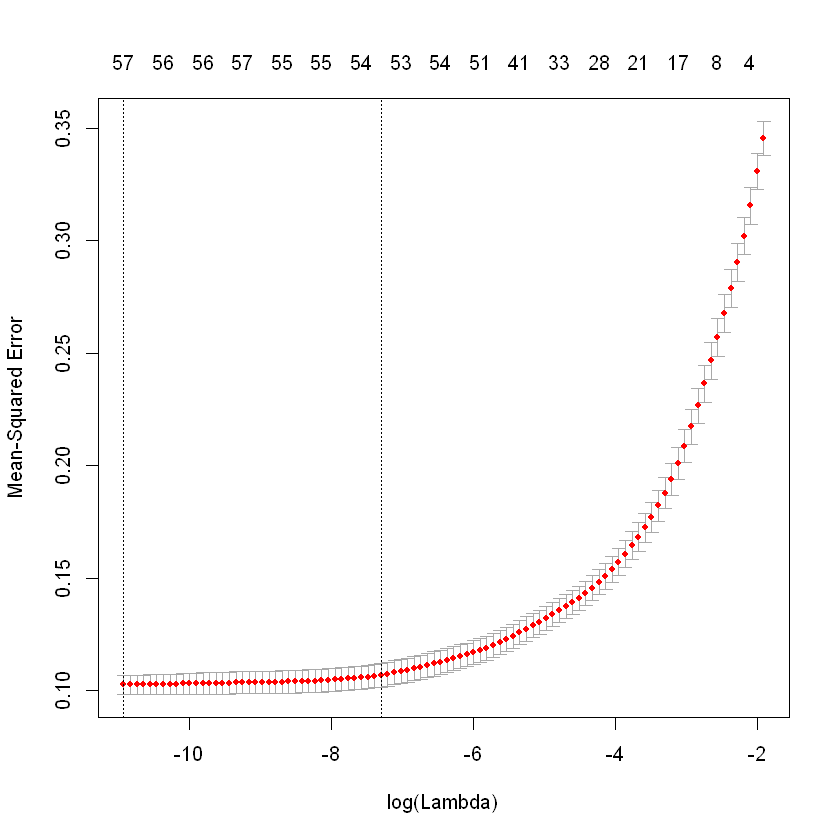

```r
plot(cvfit_spam)
```

### Lambda Values for Mean Square Error Values

```r
cvfit_spam$lambda.min
```

1.79272561636051e-05

```r
cvfit_spam$lambda.1se
```

0.000674949684198235

```r
cvfit_spam$lambda[10]
```

0.064427217664051

3 possible lambda values are determined by the cv.glmnet(). One of them is used for getting minimum Mean-Squared Error. The other one is determined by looking how many paramater is used in the model. Namely, this lambda value can be beneficial for reducing the possibility of over-fitting model on train dataset. Lastly, one random lambda was selected to compare results for these 3 lambda values.

```r
prediction_pra_mse_spam_min <- predict(lasso_model_spam_mse_min, s = cvfit_spam$lambda.min, newx = test_mat_spam,type="class")
prediction_pra_mse_spam_1se <- predict(lasso_model_spam_mse_1se, s = cvfit_spam$lambda.1se, newx = test_mat_spam,type="class")
prediction_pra_mse_spam_10th <-predict(lasso_model_spam_mse_10th, s = cvfit_spam$lambda[10], newx = test_mat_spam,type="class")
```